# Notes on Machine Learning

D Kalplan @ CVC 2017

June 16, 2017

## General Approach

1. Use a function for the method you are interested in
   1. provide it a data set and a description of the models
   2. many R fuctions use a formula to describe the repsonse and predictor variables used in the model

```r
model <- function_for_method (y ~ x1 + x2 + x3, data = SomeData)
```

2. Evaluate by predicting using the fuction that is produced by the model.

```r
predict(model, data = NewData)
```

3. Extract specific information from the model (which variables are important? how well does prediction work? plot of model? etc. etc.)

```r
extract_info_from_model(model)
```

### Toy Example showing how a partitioning step works.

```r
Toy <- data.frame(
  y = c(13, 14, 10, 17, 19, 30),
  x1 = c(3, 4, 5, 7, 9, 15),
  x2 = c("A", "A", "B", "A", "A", "B")
)
```

```r
Toy %>% group_by( x1 < 6) %>%
  mutate(y.hat = mean(y),
         resid = y - y.hat,
         r2 = resid^2
         ) %>%
  ungroup() %>%
  mutate(SSR = sum(r2))
```

```
## # A tibble: 6 x 8
##       y    x1     x2 `x1 < 6`    y.hat      resid         r2      SSR
##   <dbl> <dbl> <fctr>    <lgl>    <dbl>      <dbl>      <dbl>    <dbl>
## 1    13     3      A     TRUE 12.33333  0.6666667  0.4444444 106.6667
## 2    14     4      A     TRUE 12.33333  1.6666667  2.7777778 106.6667
## 3    10     5      B     TRUE 12.33333 -2.3333333  5.4444444 106.6667
## 4    17     7      A    FALSE 22.00000 -5.0000000 25.0000000 106.6667
## 5    19     9      A    FALSE 22.00000 -3.0000000  9.0000000 106.6667
## 6    30    15      B    FALSE 22.00000  8.0000000 64.0000000 106.6667
```

```r
Toy %>% group_by(x2) %>%
  mutate(y.hat = mean(y),
         resid = y - y.hat,
         r2 = resid^2
         ) %>%
  ungroup() %>%
  mutate(SSR = sum(r2))
```

```
## # A tibble: 6 x 7
##       y    x1     x2 y.hat  resid       r2    SSR
##   <dbl> <dbl> <fctr> <dbl>  <dbl>    <dbl>  <dbl>
## 1    13     3      A 15.75  -2.75   7.5625 222.75
## 2    14     4      A 15.75  -1.75   3.0625 222.75
## 3    10     5      B 20.00 -10.00 100.0000 222.75
## 4    17     7      A 15.75   1.25   1.5625 222.75
## 5    19     9      A 15.75   3.25  10.5625 222.75
## 6    30    15      B 20.00  10.00 100.0000 222.75
```

## Recursive Partitioning (rpart)

Also called CART (classification and rgression tree)

### KidsFeet data

```r
head(KidsFeet)
```

```
##     name birthmonth birthyear length width sex biggerfoot domhand
## 1  David          5        88   24.4   8.4   B          L       R
## 2   Lars         10        87   25.4   8.8   B          L       L
## 3   Zach         12        87   24.5   9.7   B          R       R
## 4   Josh          1        88   25.2   9.8   B          L       R
## 5   Lang          2        88   25.1   8.9   B          L       R
## 6 Scotty          3        88   25.7   9.7   B          R       R
```

### A model

```r
mod <- rpart(width ~ sex + length + biggerfoot + domhand, data = KidsFeet)
mod
```

```
## n= 39
##
## node), split, n, deviance, yval
##       * denotes terminal node
##
## 1) root 39 9.867692 8.992308
##   2) length< 25.15 25 4.561600 8.756000
##     4) sex=G 14 2.597143 8.614286 *
##     5) sex=B 11 1.325455 8.936364 *
##   3) length>=25.15 14 1.417143 9.414286 *
```

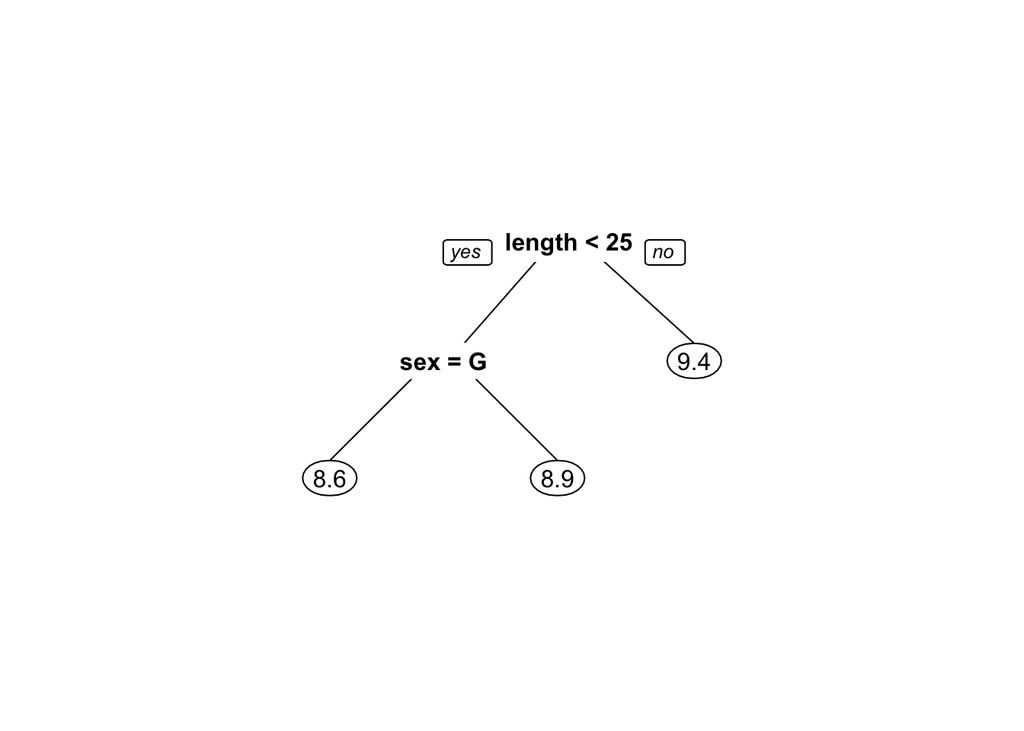

```r
prp(mod)
```

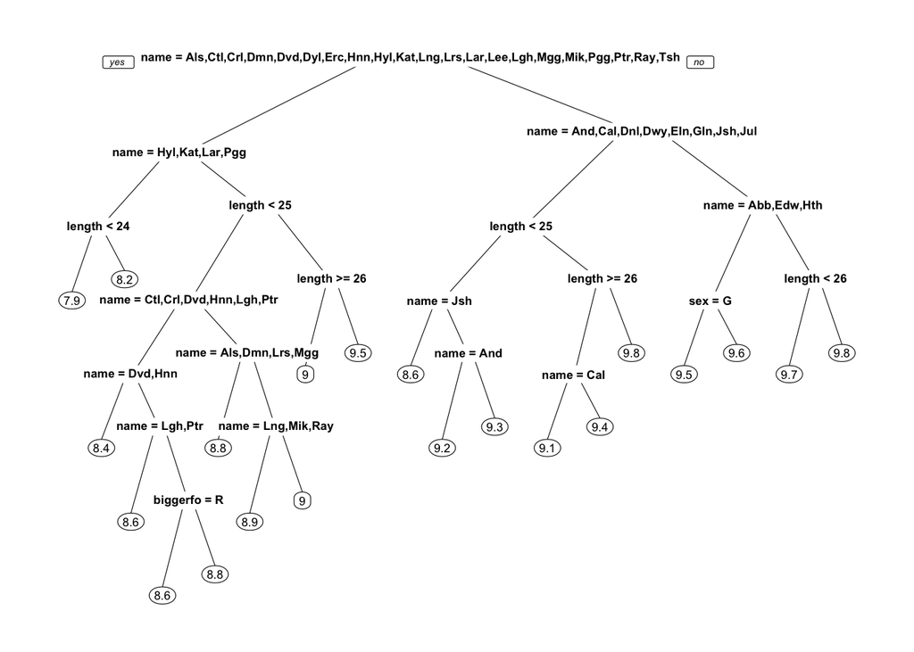

```r
mod <- rpart(width ~ sex + length + biggerfoot + domhand + name, data = KidsFeet,
             control = rpart.control(minsplit = 3, cp = 0.00001)
)
prp(mod)
```

### Cross-Validation

Train the model on some data (training data) and check how well it works on different data (testing data) and assess the quality of the model based on how well it does in the test data. This keeps the model from **overfitting** the data.

## Random Forest

Idea: Make many random trees.

1. Randomly pick a subset of the explanatory variables (often 1/3 or square root of the variables)
2. Make a CART based on just those explanatory variables.
3. Result is the average of the outputs of the trees in the forest.

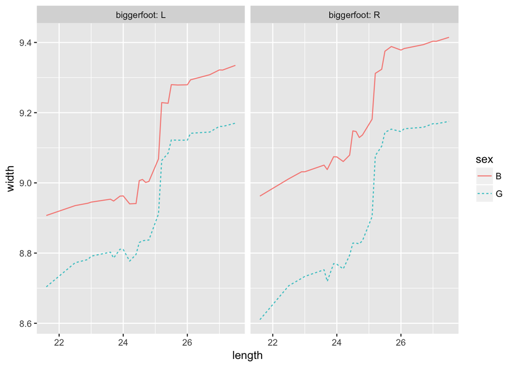

```r
require(randomForest)
mod2 <- randomForest(width ~ sex + length + biggerfoot + domhand, data = KidsFeet)
gmodel(mod2, ~ length + sex + biggerfoot)
```

```r
effect_size(mod2, ~ length)
```

```
##       slope length to:length sex biggerfoot domhand
## 1 0.2163715   24.5  25.81759   B          L       R
```

```r
importance(mod2)
```

```
##            IncNodePurity
## sex            1.0690121
## length         2.6741353
## biggerfoot     0.2885772
## domhand        0.3257205
```

### XGBoost

XGBoost (Gradient Boosted Random Forests) is the current state-of-the-art generalization of this. `xgboost` package in R will do it.

Nice introduction to the algorithm is here: http://xgboost.readthedocs.io/en/latest/model.html

## Some comments

### Other popular things

- Support Vector Machines
- Linear
- Ridge Regression
- Lasso
- Elastic Net

### These things exist in many platforms

- R typically provides an interface to the same underlying code (often in C/C++) that you can use via otehr mechanisms (like Python) as well.
- Let’s you work in R syntax using algorithms created in other programming languages.
- The origins of R go back to attempting to provide an interface to FORTRAN so that analysists wouldn’t need to write a new FORTRAN program for each analysis.

### Smoothing over differences between methods

Because different methods were coded by different people, the interfaces are not always compatible. A couple packages have tried to smooth over these differences in interface:

- `Zelig`
- `caret`

## Unsupervised Learning

Attempting to find clusters/groups in data without any “correct answers” to compare with.

### Singular Value Decomposition

See Scottish Parliment example in *Data Computing* (Kaplan)